# Research Design and Causality

Econ 440 - Introduction to Econometrics

Patrick Toche, ptoche@fullerton.edu

05 May 2022

# Research Design Identifies Causality

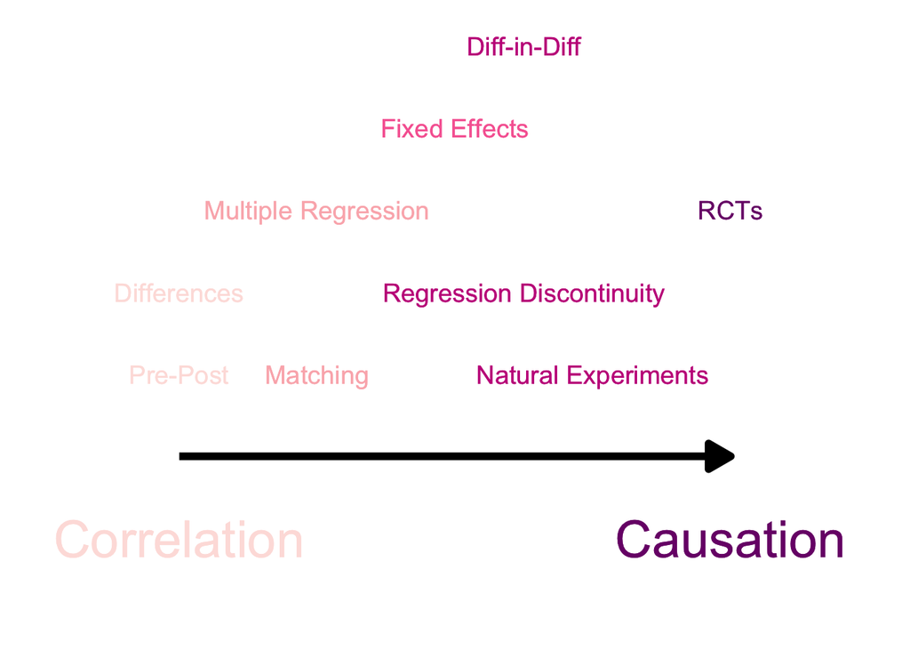

# The Problem of Endogeneity

- **Endogeneity** remains the hardest (and most common) econometric challenge
- Difference-in-Difference and Fixed Effects are used to address endogeneity
  - *Requires* panel data.
  - Cannot use time-varying omitted variables that are correlated with regressors.
- Instrumental Variables: Find some source of exogenous variation that removes the endogeneity.

# Instrumental Variables

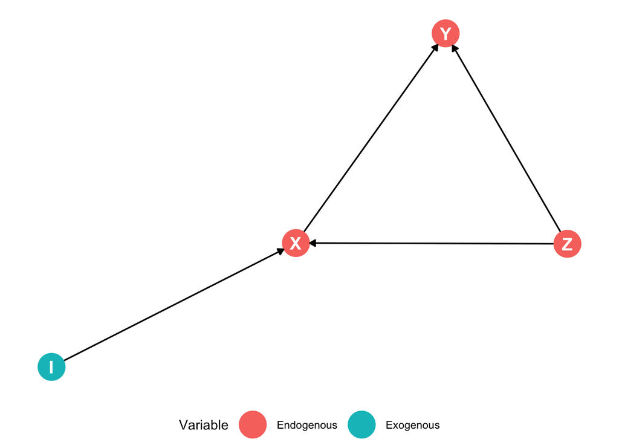

# Understanding Instrumental Variables

- **X** and **Y** are correlated
- Confounding variable **Z** that meets the conditions of omitted variable bias:
  1. Causes $Y$ (in error term $u)$
  2. Correlated with $X$
- Causality from $X$ to $Y$:
  1. $X \rightarrow Y$ (causal, front door)
  2. $X \leftarrow Z \rightarrow Y$ (non-causal, back door)
- Consider variable **I** which causes **X** but *not* **Y**
- Variable **I** has no backdoors between it and $Y$
- The only way to reach $Y$ from $I$ is through $X$:
  - $I \rightarrow X \rightarrow Y$
- Variable **I** is a good instrument for $X$ if it satisfies two conditions:
  1. **Inclusion condition:** $I$ statistically-significantly explains $X$
  2. **Exclusion condition:** $I$ is uncorrelated with $u$, so it does not directly affect $Y$
  - $I$ only affects $Y$ *through* its effect on $X$

# Example: How does veteran status affect earnings?

$$\text{Earnings}_{i}
= \beta_0+\beta_1 \, \text{Veteran}_{i}
+ \text{u}_{i}$$
- Veteran$_i$ is endogenous, correlated with other things in $u_i$ - Choice to enlist in military for non-random reasons

- We want to split variation in $X$ into an exogenous part and an endogenous part:
  $$\begin{align*}
  \text{Earnings}_i &= \beta_0 + \beta_1 \, \text{Veteran}_i + u_i \\
  \text{Earnings}_i &= \beta_0 + \beta_1
  \, (\text{Veteran}_i^{Ex.}+\text{Veteran}_i^{End.})+u_i\\
  \text{Earnings}_i &= \beta_0 + \beta_1 \, \text{Veteran}_i^{Ex.} +
  \underbrace{\beta_1 \text{Veteran}_i^{End.}+u_i}_{w_i}\\
  \text{Earnings}_i &= \beta_0 + \beta_1 \, \text{Veteran}_i^{Ex.} +
  w_i
  \end{align*}$$

–

- What would a plausible source of Veteran$_i^{Ex.}$ be?
- Choices to enlist in the military for “random” reasons, uncorrelated with $u_i$ (other things that affect Earnings$_i)$
- We isolate the *exogenous variation* in $X_i$ with an instrumental variable that is:
1. Correlated with the explanatory variable (relevance)
2. Uncorrelated with the error term (exogenous)

$$\text{Earnings}_{i}=\beta_0+\beta_1 \,
\text{Veteran}_{i}+\text{u}_{i}$$

### Relevance

- **Relevance**: we need $I_i$ to vary with our endogenous $X_i$ variable
- We can *test* this condition using a regression and $t$-test on the relevant coefficient
- **Example**: For *veteran* status, consider several potential $I_i$ variables:
1. Social security number
- **Irrelevant** uncorrelated with military service
2. Physical fitness
- **Likely relevant** may be correlated with military service
3. Vietnam War Draft
- **Relevant** being drawn in draft causes military service

### Exogeneity

- **Exogeneity:** we need $I_i$ to be “as good as randomly assigned”, uncorrelated with $u_i$ (other factors that determine $Y_i)$
- **Example**: For *veteran* status, consider several potential $I_i$ variables:
1. Social security number
- **Exogenous** uncorrelated with other factors of earnings
2. Physical fitness
- **Not exogeous** correlated with many other factors of earnings
3. Vietnam War Draft
- **Exogenous** lottery was random!

### Choice of Instrument

- Instrument must be
1. Correlated with our endogenous variable $(X_i)$
2. Uncorrelated with omitted variables that affect $Y_i$
- To summarize: **the instrument only affects the outcome through its relationship with the endogenous variable**
- **Example**: For *veteran* status, our several potential $I_i$ variables:
1. Social security number
- **Not relevant**
- **Exogenous**
2. Physical fitness
- **Relevant**
- **Not exogenous**
3. Vietnam War Draft
- **Relevant**
- **Exogenous**
- The Vietnam War Draft is the only **valid instrument**

# DAG Form

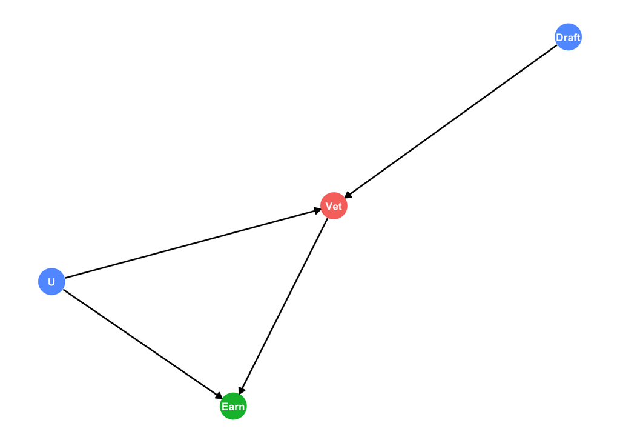

- Causal relation from $X$ to $Y$:
  1. $Vet \rightarrow Earn$
  2. $Vet \leftarrow U \rightarrow Earn$
- We want the causal effect of
- $Vet \rightarrow Earn$
- With our instrument
  - $Draft \rightarrow Vet \rightarrow Earn$
- With our instrument
  - $Draft \rightarrow Vet \rightarrow Earn$
- Based on our assumptions on independence and exogeneity:

$$(\text{Effect of the draft on earnings}) =
(\text{Effect of the draft on veteran status})
\times
(\text{Effect of veteran status on earnings})$$
- To find effect of veteran status on earnings, rearrange the equation:
$$(\text{Effect of veteran status on earnings}) =
(\text{Effect of the draft on earnings})
/
(\text{Effect of the draft on veteran status})$$
—

# Estimating Instrumental Variables

Estimate the effect of veteran status on earnings.
$$\text{Earnings}_i = \beta_0 + \beta_1 \, \text{Veteran}_i + u_i$$

- Consider two related effects:
1. Effect of instrument on the endogenous variable:
   $$\text{Veteran}_i = \gamma_0 + \gamma_1 \, \text{Draft}_i + w_i$$
2. Effect of instrument on the outcome variable:
   $$\text{Earnings}_i = \pi_0 + \pi_1 \text{Draft}_i + v_i$$
   —

# Example: Police and Crime Rate

- Police $\rightarrow$ crime (more police reduces crime)
- Crime $\rightarrow$ Police (high crime areas tend to have more police)
- $cor(\text{Police}, \text{u})\neq 0$: population, income per capita, drug use, recessions, demography, etc.
- How do (more) police affect crime rates?
  $$\text{Crime}_{it}=\beta_0+\beta_1 \,
  \text{Police}_{it}+\text{u}_{it}$$
- Police $\rightarrow$ crime (more police reduces crime)
- Crime $\rightarrow$ Police (high crime areas tend to have more police)
- $cor(\text{Police}, \text{u})\neq 0$: population, income per capita, drug use, recessions, demography, etc..
- Levitt (2002): use number of firefighters as an **instrument** for police.
- *Some* variation in Police is **endogenous**
  - More police hired to combat rising crime
  - Changes in economy, demographics, etc, correlated with crime
- *Some* variation in Police is **exogenous**
  - Some police might be hired for reasons *not* connected to crime
  - Perhaps city gets a larger budget one year
- Exogenous, non-crime-related changes affect number of *Firefighters* in a city (excess budget, etc)
  - Isolate that portion of variation in Police that covaries with Firefighters (exogenous)
  - Throw out variation in Police that is endogenous (covaries with things that vary with crime)
  - See how the exogenous variation in Firefighters helps explain variation in Crime via Police!

Levitt, Steven D, (2002), “Using Electoral Cycles in Police Hiring to Estimate the Effect of Police on Crime: Reply,” *American Economic Review* 92(4): 1244-1250.

### Two-Stage Least Squares

- Equation of interest:

$$\widehat{Y_i}
= \widehat{\beta_0}
+ \widehat{\beta_1} X_{1i}
+ \widehat{\beta_2} X_{2i}
+ \widehat{u_i}$$

- **First Stage**: use $IV$ to explain $X_{1i}$ in an **auxiliary regression**:

$$\widehat{X_{1i}}
= \hat{\gamma_0}
+ \hat{\gamma_1} Z_i
+ \hat{\gamma_2} X_{2i}
+ \hat{\epsilon_i}$$

- **Second Stage**: substitute the *predicted* value of $\widehat{X_{1i}}$ in the original regression:

$$\widehat{Y_i}
= \hat{\beta_0}
+ \hat{\beta_1} \widehat{X_{1i}}
+ \hat{\beta_2} X_{2i}
+ \hat{u_i}$$

### Understanding Instrumental Variables

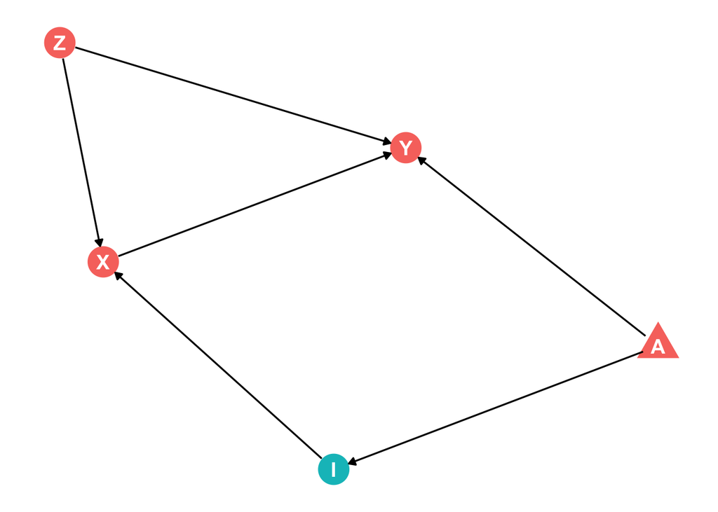